# Tugas Unsupervised Learning

Dinda Dwi Anugrah Pertiwi

2026-03-10

# HIERARCHICAL VS PARTITIONING ALGORITHM

# Hierarchical Algorithm

Algoritma pengelompokan hierarkis adalah proses yang tidak dapat dibalik yang mengulangi siklus penggabungan semua objek ke dalam sebuah kluster atau pemisahan kluster objek menjadi objek individu.

Pengelompokan hierarkis pada dasarnya adalah teknik pengelompokan tanpa pengawasan (*unsupervised*) yang melibatkan pembentukan kluster dalam urutan yang telah ditentukan sebelumnya. Kluster-kluster tersebut diurutkan secara hierarkis dari atas ke bawah.

## Kelebihan

- Tidak Perlu Menentukan Jumlah Klaster (K) di Awal
- Visualisasi (Dendogram)
- Struktur Bertingkat
- Fleksibilitas Metrik Jarak dan Linkage

## Kekurangan

- Komputasi Mahal
- Keputusan Penggabungan/Pembagian Bersifat Final
- Tidak Ada Koreksi Kesalahan
- Sulit Ditentukan Jumlah Kluster Optimal
- Sensitivitas Terhadap Noise dan Outlier
- Kurang Praktis untuk Data Sangat Besar

## Jenis

Dalam jenis pengelompokan ini, kluster-kluster yang serupa digabungkan dan disusun secara hierarkis. Teknik ini dapat dibagi menjadi dua jenis, yaitu:

### Aglomerative

Pendekatan aglomeratif dimulai dengan setiap pengamatan berada dalam kluster terpisah (*singleton*), dan secara bertahap menggabungkan kluster-kluster tersebut hingga kriteria penghentian terpenuhi. Pendekatan ini adalah pendekatan yang paling sering digunakan.

Proses Agglomerative:

- Inisialisasi: Setiap objek (titik data) dimulai sebagai klasternya sendiri (jadi, jika Anda punya N objek, Anda mulai dengan N klaster).
- Hitung Jarak: Hitung matriks jarak (menggunakan metrik seperti Euclidean, Manhattan, Gower, dll.) antara semua pasangan objek/klaster.
- Gabung (*Merge*): Temukan dua klaster yang paling dekat (paling mirip) berdasarkan matriks jarak. Gabungkan kedua klaster ini menjadi satu klaster baru.
- Perbarui Jarak: Hitung ulang matriks jarak, sekarang dengan menyertakan klaster baru. Di sinilah metode linkage berperan untuk menentukan jarak antara klaster baru ini dengan klaster lainnya.
- Ulangi: Ulangi langkah 3 dan 4 sampai semua objek tergabung dalam satu klaster besar.

### Contoh Agglomerative

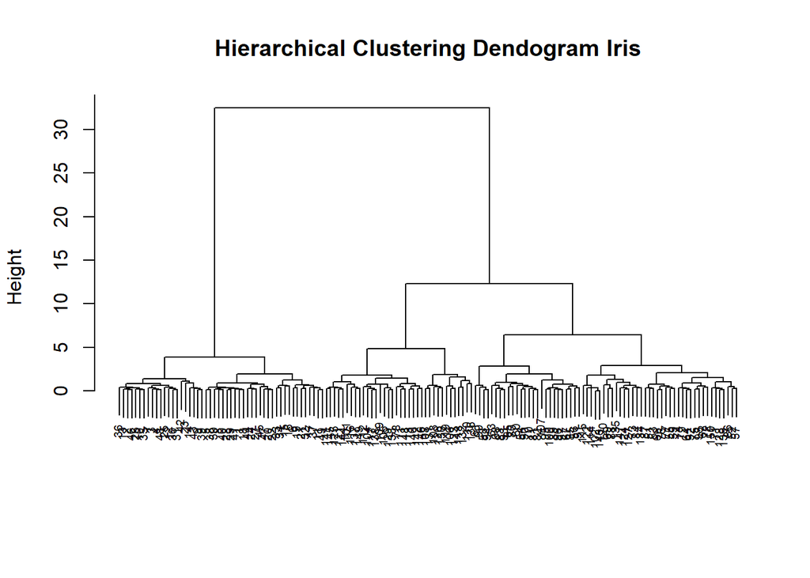

```r
#data
data_iris <- iris[,1:4]

#menghitung jarak antar data
dist_iris <- dist(data_iris)

#hierarchical clustering (agglomerative)
hie <- hclust(dist_iris, method = "ward.D2")

#dendogram
plot(hie, main = "Hierarchical Clustering Dendogram Iris",
     xlab = "",
     sub = "",
     cex = 0.6)
```

```r
#memotong dendogram menjadi 3 kluster
kluster <- cutree(hie, k = 3)
table(kluster)
```

```
## kluster
##  1  2  3
## 50 64 36
```

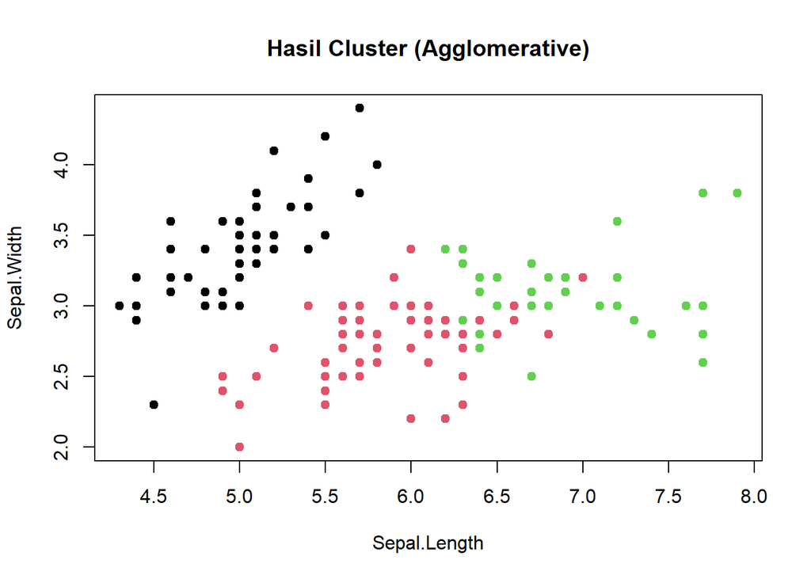

```r
#visualisasi cluster
plot(data_iris[,1:2], col=kluster, pch=19,
     main="Hasil Cluster (Agglomerative)")
```

### Divisive

Metode divisive dimulai dengan semua pola berada dalam satu kluster dan melakukan pembagian hingga kriteria penghentian terpenuhi (bekerja secara berlawanan).

Proses Divisive:

- Inisialisasi: Semua objek dimulai sebagai satu klaster besar tunggal.
- Bagi (Split): Pada setiap langkah, klaster yang ada dipilih dan dibagi menjadi dua sub-klaster yang paling “berbeda” atau “heterogen”.
- Ulangi: Proses pembagian ini diulangi sampai setiap objek berada dalam klasternya sendiri, atau sampai kriteria penghentian tertentu terpenuhi (misalnya, jumlah klaster yang diinginkan).

Pendekatan:

- Berbasis Keterpisahan: Mencari cara membagi klaster sehingga jarak antar dua sub-klaster baru menjadi maksimal.
- Berbasis Kohesi: Mencari cara membagi sehingga dalam setiap sub-klaster baru, objek-objeknya se-homogen mungkin.
- Algoritma DIANA (*DIvisive ANAlysis*): Salah satu algoritma divisif yang lebih dikenal. Ia bekerja dengan mencari objek dalam sebuah klaster yang paling tidak mirip dengan objek lain, lalu memulai sub-klaster baru dengannya dan memindahkan objek lain yang lebih dekat ke sub-klaster baru tersebut.

### Contoh Divisive

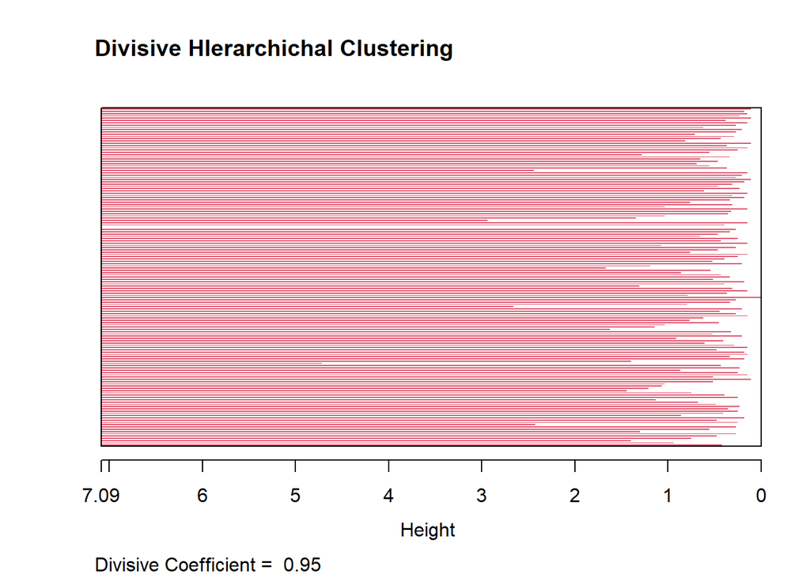

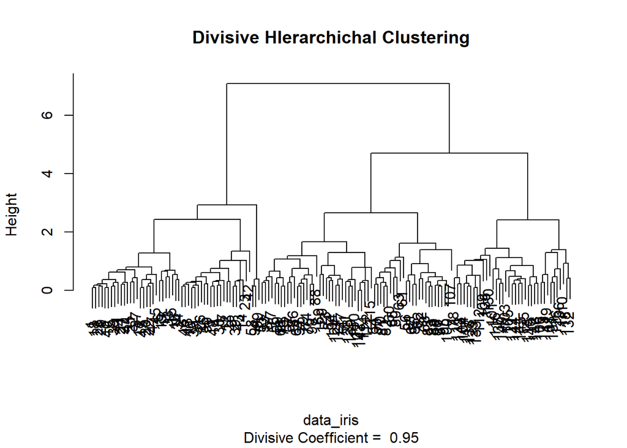

```r
#package
library(cluster)

#data
data_iris <- iris[,1:4]

#divisive hierarchical
divs <- diana(data_iris)

#dendogram
plot(divs, main = "Divisive HIerarchichal Clustering")
```

## Perbandingan

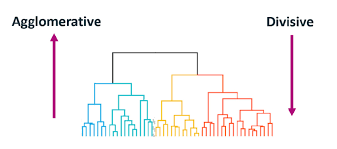

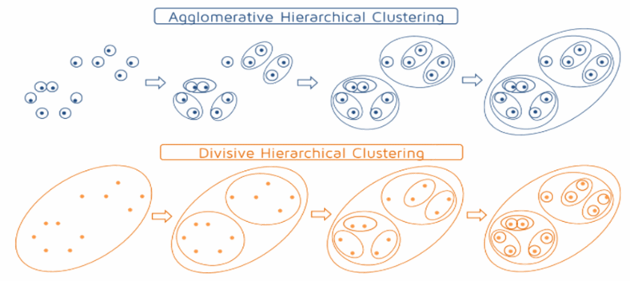

| Metode | Cara Kerja |
| --- | --- |
| Agglomerative | menggabungkan kluster kecil menjadi kluster besar (*bottom-up*) |
| Divisive | memecah kluster besar menjadi kluster kecil (*top-down*) |

# Partitioning Algorithm

algoritma clustering partisi menghasilkan partisi yang beragam, yang dievaluasi berdasarkan kriteria yang telah ditentukan, misalnya dengan meminimalkan jarak antara objek dan pusat kluster. Algoritma ini menugaskan objek ke pusat yang paling dekat yang telah ditentukan sebelumnya dan memperkirakan ulang pusat-pusat tersebut berdasarkan anggota saat ini. Proses ini diulang hingga konvergensi. Pilihan populer untuk algoritma partisi adalah k-means dan partisi sekitar medoid (Hastie dkk., 2009; Leisch, 2006).

## Kelebihan

- Algoritma sederhana
- Efisien untuk dataset besar
- Mudah diimplementasikan secara komputasi
- Output mudah diinterpretasikan

## Kekurangan

- Jumlah kluster harus ditentukan di awal
- Hasilnya sensitif terhadap pemilihan sentroid awal
- Kurang efektif untuk data dengan bentuk kluster kompleks
- Sensitif terhadap outlier

## Jenis

Pada partitioning clustering jenisnya biasanya dibedakan berdasarkan algoritmanya, bukan cara pembentukannya, jenis yang paling umum dari partitioning adalah:

### K-Means

Metode yang membagi data ke dalam K cluster berdasarkan rata-rata (*mean*) dari setiap cluster.

Proses Kmeans:

- Inisialisasi (menentukan jumlah K, menentukan sentroid awal)
- Iterasi (langkah penugasan, langkah pembaruan)
- Kondisi Berhenti (ulangi langkah 2 sampai salah satu kondisi terpenuhi (konvergensi, sentroid stabil, jumlah iterasi max))

### Contoh K-Means

```r
#data
data_iris <- iris[,1:4]

#kmeans
set.seed(010)
kmeans_iris <- kmeans(data_iris, centers = 3)
kmeans_iris$cluster
```

```
##   [1] 2 2 2 2 2 2 2 2 2 2 2 2 2 2 2 2 2 2 2 2 2 2 2 2 2 2 2 2 2 2 2 2 2 2 2 2 2
##  [38] 2 2 2 2 2 2 2 2 2 2 2 2 2 3 3 1 3 3 3 3 3 3 3 3 3 3 3 3 3 3 3 3 3 3 3 3 3
##  [75] 3 3 3 1 3 3 3 3 3 3 3 3 3 3 3 3 3 3 3 3 3 3 3 3 3 3 1 3 1 1 1 1 3 1 1 1 1
## [112] 1 1 3 3 1 1 1 1 3 1 3 1 3 1 1 3 3 1 1 1 1 1 3 1 1 1 1 3 1 1 1 3 1 1 1 3 1
## [149] 1 3
```

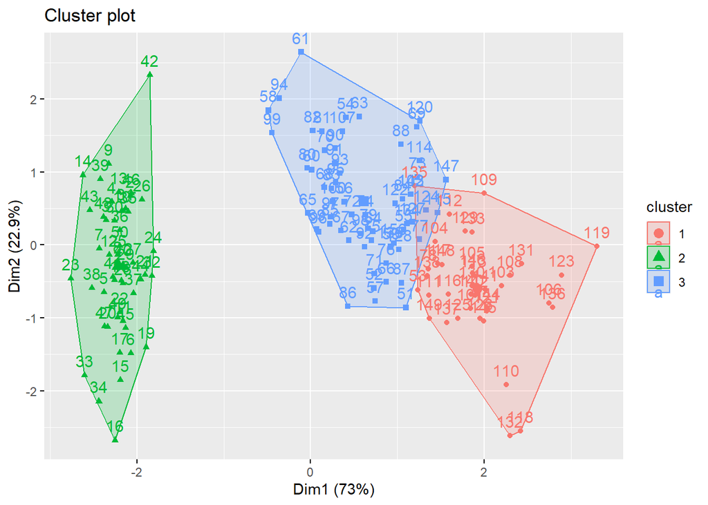

```r
#package
library(factoextra)

#visualisasi
fviz_cluster(kmeans_iris, data = data_iris)
```

### K-Medoids

Mirip dengan K-Means tetapi pusat cluster adalah data asli (*medoid*), bukan rata-rata.

Proses Kmedoids:

- Inisialisasi (pilih K, pilih medoid awal)
- Langkah penugasan (hitung jaraknya ke setiap K, tugaskan objek ke kluster terdekat)
- Langkah Pembaruan (mengganti medoid dengan non medoid)
- Lakukan pengulangan sampai tidak ada perubahan

### Contoh K-Medoids

```r
#package
library(cluster)
library(factoextra)

#data
data_iris <- iris[,1:4]

#kmedoids pam
model_pam <- pam(data_iris, k = 3)
model_pam$clustering
```

```
##   [1] 1 1 1 1 1 1 1 1 1 1 1 1 1 1 1 1 1 1 1 1 1 1 1 1 1 1 1 1 1 1 1 1 1 1 1 1 1
##  [38] 1 1 1 1 1 1 1 1 1 1 1 1 1 2 2 3 2 2 2 2 2 2 2 2 2 2 2 2 2 2 2 2 2 2 2 2 2
##  [75] 2 2 2 3 2 2 2 2 2 2 2 2 2 2 2 2 2 2 2 2 2 2 2 2 2 2 3 2 3 3 3 3 2 3 3 3 3
## [112] 3 3 2 2 3 3 3 3 2 3 2 3 2 3 3 2 2 3 3 3 3 3 2 3 3 3 3 2 3 3 3 2 3 3 3 2 3
## [149] 3 2
```

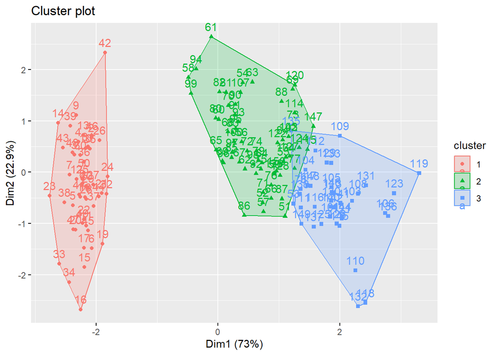

```r
#visualisasi
fviz_cluster(model_pam, data = data_iris)
```

### DBSCAN

DBSCAN (*Density-Based Spatial Clustering of Applications with Noise*) adalah algoritma clustering berbasis kepadatan data (*density*). Metode ini mengelompokkan data berdasarkan kepadatan titik dalam suatu area.

Proses DBSCAN:

- Pemilihan parameter (menentukan nilai eps dan MinPts)
- Inisialisasi (tandai semua titik sebagai *unvisited*)
- Iterasi : mulai dari titik acak yang belum dikunjungi (tandai, cek lingkungan, evaluasi kepadatan)
- Ekspansi kluster
- Ulangi (kembali ke langkah 3)

### Contoh DBSCAN

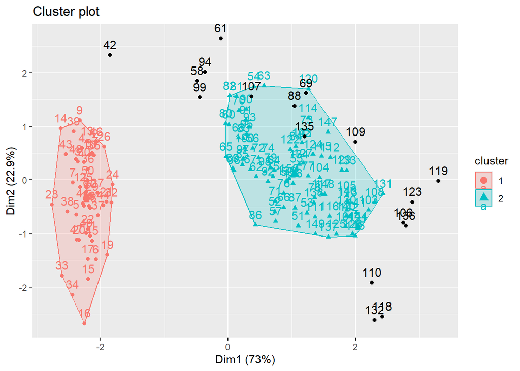

```r
#package
library(dbscan)
library(factoextra)

#data
data_iris <- iris[,1:4]

#dbscan
db_model <- dbscan(data_iris, eps = 0.5, minPts = 5)

#visualisasi
fviz_cluster(db_model, data = data_iris)
```

### CLARA

CLARA adalah pengembangan dari K-Medoids yang dirancang untuk dataset besar.

Proses CLARA:

- Inisialisasi (set minimum cost ke nilai yang paling besar)
- Loop pengambilan sampel : ulangi sebanyak S (ambil sampel, jalankan PAM, hitung biaya, bandingkan dan simpan)
- Output
- Penugasan akhir (tugaskan setiap objek dalam dataset ke medoid terdekat)

### Contoh CLARA

```r
#package
library(cluster)
library(factoextra)

#data
data_iris <- iris[,1:4]

#clara
cla_model <- clara(data_iris, k = 3)
cla_model$clustering
```

```
##   [1] 1 1 1 1 1 1 1 1 1 1 1 1 1 1 1 1 1 1 1 1 1 1 1 1 1 1 1 1 1 1 1 1 1 1 1 1 1
##  [38] 1 1 1 1 1 1 1 1 1 1 1 1 1 2 2 3 2 2 2 2 2 2 2 2 2 2 2 2 2 2 2 2 2 2 2 2 2
##  [75] 2 2 2 3 2 2 2 2 2 2 2 2 2 2 2 2 2 2 2 2 2 2 2 2 2 2 3 2 3 3 3 3 2 3 3 3 3
## [112] 3 3 2 3 3 3 3 3 2 3 2 3 2 3 3 2 2 3 3 3 3 3 2 3 3 3 3 2 3 3 3 2 3 3 3 2 3
## [149] 3 2
```

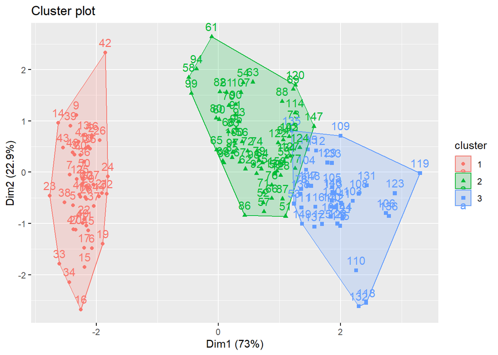

[output not shown]

```r
#visualisasi
fviz_cluster(cla_model, data = data_iris)
```

# Hierarchical Vs Partitioning

| Aspek | Hierarchical | Partitioning |
| --- | --- | --- |
| Konsep dasar | Membentuk struktur kluster secara bertahap | Membagi data langsung menjadi beberapa kluster |
| Pendekatan | Bertahap (bottom - up atau top - down) | Iteratif berdasarkan pusat kluster |
| Penentuan jumlah kluster | Tidak harus idtentukan di awal | harus ditentukan di awal (nilai K) |
| struktur hasil | Menghasilkan dendogram | Tidak menghasilkan dendogram |
| Kompleksitas komputasi | Lebih tinggi | Lebih efisien untuk dataset besar |
| Sensitivitas terhadapat outlier | Relatif lebih stabil | Beberapa metode sensitif terhadap outlier |
| Fleksibilitas bentuk kluster | Dapat menemukan struktur data | Biasanya cocok untuk kluster berbentuk bulat |
| algoritma | Agglomerative, Divisive | K-Means, K-Medoids, DBSCAN< CLARA |

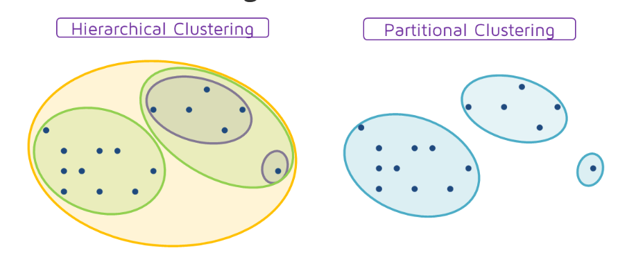